# Guiding Question 1 (Alister): How have the counts of different permit types changed since 2000?

## Domain

Through the 21st century, there have been world events and cultural shifts such as the COVID-19 pandemic and the 2008 economic crisis. Are these events reflected in the permit types applied for? Can we see any growing or dying trends in permit types? Could there be less residential building permits now than before, leading to the current housing crisis? The notebook looks to visualize the different counts of building permits to see some questions can be answered.

## Data Set

The data used in the exploration of this guiding question was categorical data exported from the Building Permits from Open Calgary, of which the terms of use indicate that the data is in a CSV format (The City of Calgary, 2023). This dataset has over 425,000 entries ranging from mid-1999 to today. To ensure efficient handling of data in code, only select columns were chosen and downloaded. To select these columns, Open Calgary's dataset query service was used. There were various columns such as the applied date, completion date, permit type, work class, location, community, etc. Although the dataset provides its own permit type, their were over 100 different types to consider and group together. Instead of organizing these permit types manually, it was decided to produce new permit types that fitted our project and was easy to classify; these new permit types will be called *permit designations*.

With the data collected, clearly defined permit designations must be made. The five permit designations that were defined were

1. New Residential: new housing units such as single family, duplexes, etc.
2. New Non-Residential: new buildings that are not for housing such as stores, warehouses, etc.
3. Improvement: improvements to pre-existing buildings such as decks, fireplaces, fences, etc.
4. Demolition: destruction of a building
5. Additional Dwelling: improvements for the purpose of housing like secondary suites, basement suites, etc.

The columns used to classify the permits were `WorkClassGroup`, `PermitClassMapped`, and `PermitClassGroup`.

- `WorkClassGroup` determines whether a permit is new, improvement, or demolition.
- `PermitClassMapped` determines whether a permit is residential or non-residential
- `PermitClassGroup` determines whether a permit is an additional dwelling or not.

```python
import pandas as pd
import matplotlib.pyplot as plt
```

# Applying Chosen Permit Types

## Purpose

Before we can start to visualize the data, permit designations must be applied to each permit.

## The Process

First, import the data and understand it's structure.

```python
df = pd.read_csv('data_q1.csv')
df.info()
```

```
<class 'pandas.core.frame.DataFrame'>
RangeIndex: 426209 entries, 0 to 426208
Data columns (total 11 columns):
 #   Column             Non-Null Count   Dtype
---  ------             --------------   -----
 0   PermitNum          426209 non-null  object
 1   AppliedDate        426209 non-null  object
 2   PermitType         426209 non-null  object
 3   PermitTypeMapped   426209 non-null  object
 4   PermitClass        426160 non-null  object
 5   PermitClassGroup   426209 non-null  object
 6   PermitClassMapped  426209 non-null  object
 7   WorkClass          426209 non-null  object
 8   WorkClassGroup     426209 non-null  object
 9   WorkClassMapped    423261 non-null  object
 10  Description        385293 non-null  object
dtypes: object(11)
memory usage: 35.8+ MB
```

The columns used to designate the permits are `PermitClassGroup`, `PermitClassMapped`, and `WorkClassGroup`.

What values do these columns take?

```python
print(df['PermitClassGroup'].unique())
print(df['PermitClassMapped'].unique())
print(df['WorkClassGroup'].unique())
```

```
['Single Family' 'Two Family' 'Garage' 'Commercial' 'Additional Dwelling'
 'Apartment' 'Unspecified' 'Secondary Suites' 'Townhouse' 'General'
 'Institutional' 'Special Function Ten' 'Industrial' 'Government'
 'Swimming Pool' 'Retaining Wall']
['Residential' 'Non-Residential' 'Unspecified']
['New' 'Demolition' 'Unspecified' 'Improvement']
```

Depending on each column value, the permit will take a different designation. This is how they were determined, in order,

1. Additional Dwelling: `PermitClassGroup` takes values `'Additional Dwelling'` or `'Secondary Suites`'. Otherwise,
2. Demolition: `WorkClassGroup` takes the value `'Demolition'`. Otherwise,
3. Improvement: `WorkClassGroup` takes the value `'Improvement'`. Otherwise,
4. New Residential: `WorkClassGroup` takes the value `'New'` and `PermitClassMapped` takes the value `'Residential'`. Otherwise,
5. New Non-Residential: `WorkClassGroup` takes the value `'New'` and `PermitClassMapped` takes the value `'Non-Residential'`. Otherwise,
6. `None`: none of the above conditions are met.

A function was created in such a way that a permit can be entered and it will return the appropriate designation.

```python
def designation(series) :
    workClassGroup = series['WorkClassGroup']
    permitClassMapped = series['PermitClassMapped']
    permitClassGroup = series['PermitClassGroup']
    if permitClassGroup == 'Additional Dwelling' or permitClassGroup == 'Secondary Suites' : return 'additional_dwelling'
    if workClassGroup == 'Demolition' : return 'demolition'
    if workClassGroup == 'Improvement' : return 'improvement'
    if workClassGroup == 'New' :
        if permitClassMapped == 'Residential' : return 'new_residential'
        if permitClassMapped == 'Non-Residential' : return 'new_non_residential'
    return None
```

Now, create a new column called `Designation` and populate it with the output from the function `designation`

```python
df['Designation'] = df.apply(designation, axis=1)
```

Next, drop all the `None` values in the `Designation` column. This is acceptable since the question is concerned about trends rather than quantitative insights.

```python
df.dropna(subset=['Designation'], inplace=True)
```

Finally, convert the `AppliedDate` column from text to `datetime`

```python
df['AppliedDate'] = pd.to_datetime(df['AppliedDate'])
```

Now, the appropriate designations are applied and each permit has a designation.

```python
df.info()
```

```
<class 'pandas.core.frame.DataFrame'>
Index: 423096 entries, 0 to 426208
Data columns (total 12 columns):
 #   Column             Non-Null Count   Dtype
---  ------             --------------   -----
 0   PermitNum          423096 non-null  object
 1   AppliedDate        423096 non-null  datetime64[ns]
 2   PermitType         423096 non-null  object
 3   PermitTypeMapped   423096 non-null  object
 4   PermitClass        423047 non-null  object
 5   PermitClassGroup   423096 non-null  object
 6   PermitClassMapped  423096 non-null  object
 7   WorkClass          423096 non-null  object
 8   WorkClassGroup     423096 non-null  object
 9   WorkClassMapped    423095 non-null  object
 10  Description        382913 non-null  object
 11  Designation        423096 non-null  object
dtypes: datetime64[ns](1), object(11)
memory usage: 42.0+ MB
```

# Visualization

First, provide each designation with a specific colour.

```python
labels = ['Demolition','Improvement','New Residential','New Non-Residential','Additional Dwelling']
colors = ['dimgrey',   'plum',       'lightskyblue',    'palegreen',          'cornflowerblue']
color_dict = dict(zip(labels,colors))
```

Next, an overview of all the permits.

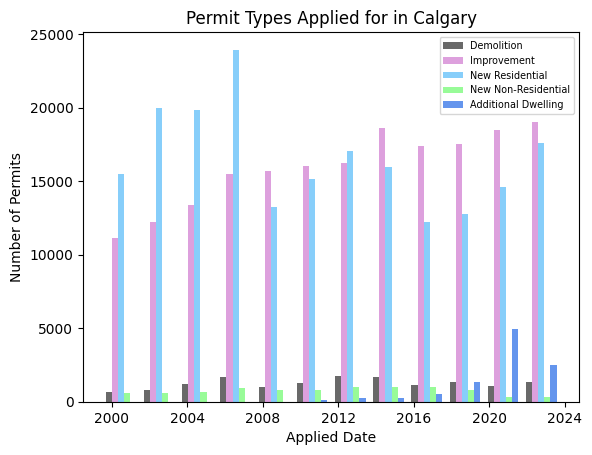

```python
plt.hist(x=[ df[df['Designation'] == 'demolition']['AppliedDate'],
             df[df['Designation'] == 'improvement']['AppliedDate'],
             df[df['Designation'] == 'new_residential']['AppliedDate'],
             df[df['Designation'] == 'new_non_residential']['AppliedDate'],
             df[df['Designation'] == 'additional_dwelling']['AppliedDate'] ],
         bins=12, color=colors, label=labels)
plt.legend(fontsize='x-small')
plt.title('Permit Types Applied for in Calgary')
plt.xlabel('Applied Date')
plt.ylabel('Number of Permits');
```

Most of the permits are `Improvement` and `New Residential`.

What about the others?

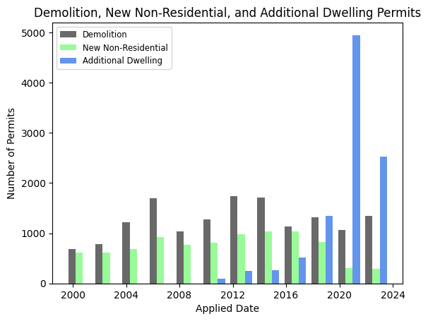

```python
input_labels = ['Demolition', 'New Non-Residential', 'Additional Dwelling']
plt.hist(x=[ df[df['Designation'] == 'demolition']['AppliedDate'],
             df[df['Designation'] == 'new_non_residential']['AppliedDate'],
             df[df['Designation'] == 'additional_dwelling']['AppliedDate'] ],
         bins=12, color=[color_dict[temp] for temp in input_labels], label=input_labels)
plt.legend(fontsize='small')
plt.title('Demolition, New Non-Residential, and Additional Dwelling Permits')
plt.xlabel('Applied Date')
plt.ylabel('Number of Permits');
```

Large increase in `Additional Dwellings` recently and a sharp decline in `New Non-Residential` following the start of the pandemic.

# Key Takeaways

*Permit Types Applied for in Calgary*

- Most of the permits are new residential and improvements
- Improvements looks steadily increasing
- Effect of 2008 crisis see in new residential permits

# Conclusion

Various world events and cultural shifts can be seen in the building permits. The effect of the 2008 housing crisis can be seen in the new residential permit counts. Due to the economy weakening, it was more difficult to start and complete new residential projects. Next, the effect of the COVID-19 pandemic could be seen in the number of new non-residential permits applied for. Notice that this permit designation consists of new commercial buildings for new businesses, businesses expanding, or business moving. Therefore, during lockdowns and decreased mobility, it was difficult for physical businesses, such as retail and diners, to launch and also expand. Finally, it is interesting to see the almost exponential increase in additional dwellings indicating a cultural shift to combat the housing crisis. It would be insightful to return to this project in the future with updated data to visualize how the number of additional dwelling permits has changed.

# References

Building Permits | Open Calgary. (n.d.). Retrieved October 18, 2023, from https://data.calgary.ca/Business-and-Economic-Activity/Building-Permits/c2es-76ed

API reference—Pandas 2.1.1 documentation. (n.d.). Retrieved October 18, 2023, from https://pandas.pydata.org/docs/reference/index.html#api

matplotlib.pyplot—Matplotlib 3.8.0 documentation. (n.d.). Retrieved October 18, 2023, from https://matplotlib.org/3.8.0/api/pyplot_summary.html